# REST_API_Examples

### The presented examples are in line with EDMtruePLM version 4.0

**Document Release Date : 31/10/2023**

```python
'''
The required libraries to be intsalled for running the examples are shown below

pip install requests numpy pandas

Please note that the additional libraries sys, time, random, datetime, json, pprint and  csv
are part of the Python standard library and do not require separate installations.
'''

import requests
import numpy as np
import pandas as pd
import sys
import time
import random
import datetime
import json
import pprint
import csv
from pathlib import Path
pp=pprint.PrettyPrinter()
```

```
This document serves as a comprehensive guide to interact with EDMtruePLM's API for various CRUD (Create, Read, Update, Delete) operations. The API examples provided below demonstrate how users can perform these actions efficiently.

1. Generating a Token:
The first step in interacting with the EDMtruePLM API is to generate an authentication token. This token will be used in subsequent API calls to authenticate the user and grant access to perform operations on the platform.

2. Creating a Project Breakdown Structure:
Once the token is generated, users can proceed to create a project breakdown structure. This involves importing a CAD model in STEP file format. The platform will analyze the CAD model and automatically generate breakdown elements based on its components. These breakdown elements could represent different parts, subassemblies, or even individual objects in the CAD model.

3. Creating Breakdown Elements in the Project:
After the initial breakdown structure is created, users have the flexibility to add or create additional breakdown elements as needed. For instance, if a new component is added to the project or if there are manual modifications required, users can use the API methods to create these new breakdown elements.

4. Searching for Breakdown Elements:
To efficiently manage large projects and datasets, the API provides methods to search for specific breakdown elements based on various parameters. Users can search for elements by name, ID, properties, or other relevant criteria. This ensures easy navigation and access to the required information.

5. Updating User Defined Breakdown Properties:
In some cases, users may need to customize or add specific properties to their breakdown elements to store additional data. The API provides methods to update these user-defined properties, allowing for a more tailored and flexible data structure within the platform.

6. Document Upload, Search, and Delete Methods:
Apart from managing the CAD model and breakdown structure, the API also supports document management within breakdown elements. Users can upload relevant documents related to each element, search for documents, and delete documents when necessary. This feature enhances data organization and makes it easy to associate relevant documentation with specific project components.

In summary, the document provides users with a comprehensive set of API call examples to interact with EDMtruePLM effectively. From generating tokens for authentication to creating project breakdown structures, managing breakdown elements, and handling associated documents, the API methods covered in the examples empower users to perform CRUD operations efficiently and facilitate seamless project management within the platform.
```

#### The API includes the following methods: POST, GET, DELETE, and PUT methods, and the responses can be any of the following:

- "200":{"description": "OK"}
- "401":{"description": "Unauthorized"}
- "403":{"description": "Forbidden"}
- "404":{"description": "Not Found"}

Note:The JSON responses containing time information from a REST API,is expressed in Coordinated Universal Time (UTC).It's essential to be aware of the UTC representation in API responses, especially if your application operates in different time zones.

#### 1. API Call for generating token

To utilize the EDMtruePLM REST APIs, a token is required . The call is POST /api/admin/token ,which returns new server connection token

```
The data types of the Input parameters of the Method are
{
    "clientURL":"string",
    "server"   :"string",
    "port"     :"string",
    "group"    :"string",
    "user"     :"string",
    "pass"     :"string"}
The output from the API method is in JSON format and the data types of the output response is

{
  "error": "string",
  "name": "string",
  "token": "string",
  "use2FA": "boolean"}

Example of the Output response

{'error': 'null',
 'name': 'null',
 'token': 'VT2MH5XITDBJY9JRLK',
 'use2FA': 'false'}
```

```python
PLM_URL = "http://localhost:8080/EDMtruePLM"         # change this to project specific URL
get_token_url = PLM_URL + "/api/admin/token"             # API to get token

def get_token(getTokenData):
    try:
        print("Performing request: " + get_token_url )
        response = requests.post(get_token_url , data=getTokenData, timeout=2.0)
        response.raise_for_status()
        if 'token' in response.json():
            token = response.json()["token"]
            return token
        else:
            print("Error: Token not found in the response.")
    except requests.exceptions.RequestException as e:
         print('Request failed {}\nError Message:  {}'.format(e, response.text))

getTokenData = {
    "group": "sdai-group",            # User group constant for EDMtruePLM application
    "user": "user_name",               # PLM User name
    "pass": "password"            # PLM Password
}

token = get_token(getTokenData)
if token:
    print("The token is:", token)
```

#### 2. API call for creating new project in EDMtruePLM

```
The API call for creating new project is, POST: /api/adm_user/{token}

In the example below Palfinger_Crane_Assembly.stp is used as input for creating a new project.
User can use their own STEP file to create a project. The image below shows the imported project
after API execution.
```

[figure not shown]

```python
##################### Create new project ######################

#Input parameters for the API method

data_param={}

file = {'file': open("Palfinger_Crane_Assembly.stp",'r')} #  declaring the required step file path (.stp, .txt, .dex)

data_param={"descr":"Crane assembly",                     # description of the creating project
            "folder":"",                                  # Project folder for the new project placement
            "is_bkd_tmpl":"false",                        # Create new project as a breakdown template(true) or not(false)
            'is_tmpl':"false",                            # Create new project as a project template(true) or not(false)
            'name':"Palfinger_Crane_Assembly",            # User required Name of the Project
            'nodeType':"",                                # node type
            'src':"pdm",                                  # Type of the data file (pdm for STEP files)
            'tmpl':""}                                    # Project template model name for the new project initialization


def create_new_project(data_param, file, token):
    create_new_proj = PLM_URL + "/api/adm_user/" + token

    print("\nPerforming request: " + create_new_proj)

    try:
        response = requests.post(create_new_proj, files=file, data=data_param, timeout=30.0)
        response.raise_for_status()
        return response.json() if response.ok else None
    except requests.exceptions.RequestException as e:
        print('Request failed {}\nError Message:  {}'.format(e, response.text))
        return None


token = get_token(getTokenData)
if token:
    new_project_information = create_new_project(data_param, file, token)
    if new_project_information:
        pp.pprint(new_project_information)
```

#### 3.API call for retrieving all projects information associated with the current EDMtruePLM user

```
 GET /api/adm_user/all_user_proj/{token}, to generate a list of projects associated with the user

This method is used to obtain an overview of projects created by the EDMtruePLM user. This call returns meta data of projects such as project name, project creation and end dates.
```

[figure not shown]

```python
##################### project information ######################

def get_current_projects_info(token):

    url_get_proj_info=PLM_URL+'/'+'api/adm_user/all_user_proj'+'/'+token   # URL for getting the projects info
    print("\nPerforming request: " +  url_get_proj_info)

    try:
        response = requests.get(url_get_proj_info, timeout=2.0)
        response.raise_for_status()
        return response.json() if response.ok else None
    except requests.exceptions.RequestException as e:
        print('Request failed {}\nError Message:  {}'.format(e, response.text))
        return None

token = get_token(getTokenData)
if token:
    projects_information = get_current_projects_info(token)
    if projects_information:
        for project_info in projects_information:
            project_name = project_info['in_project']['name']
            project_guid = project_info['in_project']['guid']
            print('\nProject name: {}, guid: {}'.format(project_name, project_guid))
```

#### 4. API call for retrieving the project's root break down element

```
GET /api/bkd/{repository}/{model}/{token}, Return the root breakdown element in the project.

This method requires two input parameters (model, repository) and returns the
root breakdown element information in the project

model - It is the Project name in EDMtruePLM
repository - "TruePLMprojectsRep” is a fixed value for all EDMtruePLM projects
```

```python
#####################  root_bd element infomration ######################


def get_root_breakdown_element(model,token,repository='TruePLMprojectsRep'):

    url_get_root_bd_info = PLM_URL + "/api/bkd/" + repository + "/" + model + "/" + token
    print("\nPerforming request: " + url_get_root_bd_info)
    try:
        response= requests.get(url_get_root_bd_info, timeout=2.0)
        response.raise_for_status()
        return response.json() if response.ok else None
    except requests.exceptions.RequestException as e:
        print('Request failed {}\nError Message:  {}'.format(e, response.text))
        return None

# Input parameters


model = "Palfinger_Crane_Assembly"

token = get_token(getTokenData)

if token:
    root_bd = get_root_breakdown_element(model,token)
    print(root_bd)
    if root_bd:
        print('The root bd element of the project: {}, and instance_id is: {}'.format(
            root_bd['root_bkdn_elem']['name'],
            root_bd['root_bkdn_elem']['instance_id']
        ))
```

#### 5.API call for creating new breakdown element

```
This method is used in the project to create a new breakdown element.

Post /api/bkd/create/{repository}/{model}/{node}/{token}

In this method user need to specify the path in form of node id such that the required new breakdown element
will be created under this path. In this figure the user wants to create a new breakdown element 'SENSORS'
under the root node of the project.

Note: For demonstration purposes, the node number (instance id) in these examples is assigned explicitly.
Nevertheless, it is usually advised against using the node numbers directly by the user.
Instead, User must employ element search techniques to find the instance id and then assign it to the
node parameter in API calls.

Instance id values cannot be used as permanent identifiers.
they may change during cut/paste and export/import operations of the project
```

[figure not shown]

```python
#####################  Creating new BD element ######################


def create_new_bd_element(node,model,data_param,token,repository="TruePLMprojectsRep"):

    create_new_bd_ele_url=PLM_URL+"/api/bkd/create"+"/"+repository + "/" + model + "/" + node + "/"+token
    print("\nPerforming request: " + create_new_bd_ele_url)
    try:
        response = requests.post(create_new_bd_ele_url,params=data_param,timeout=2.0)
        response.raise_for_status()
        return response.json() if response.ok else None
    except requests.exceptions.RequestException as e:
        print('Request failed {}\nError Message:  {}'.format(e, response.text))
        return None

# Required input parameters

node= '214748369406'                                           # provide required node path

model= 'Palfinger_Crane_Assembly'                              # Project name

data_param={'act_timestamp':'',                                # Current time stamp
           'descr':'stores sensors data',                      # Description of element
           'name':'SENSORS',                                   # Required Breakdown element name
           'nodeType':'urn:rdl:epm-std:Unit',                  # Node type
           'tmpl':''}                                          # Name of the breakdown template

token = get_token(getTokenData)
if token:
    new_element=create_new_bd_element(node,model,data_param,token)
    if new_element:
        pp.pprint(new_element)
```

#### 6.API call for breakdown elements Quick Search

```
1.GET /api/bkd/q_search/{repository}/{model}/{token}, quick search for the breakdown element

2.GET /api/bkd/q_search_ext/{repository}/{model}/{token}, quick Search breakbown elements by string pattern with
row number

The aforementioned methods are used to look for breakdown elements in a Project and find relevant properties.

Based on the query parameters, the first function's output provides details on the required breakdown element's
attributes.

Based on the query parameters, the second function's output returns information on the breakdown element's
characteristics. Additionally, the JSON output response includes the following information:

["page": 1, "page_size": 100, "total_rows"]

The total_rows displays the quantity of elements discovered using the specified query parameters.

The node option specifies the exact path in the tree to search for the required Breakdown element
```

```python
######################## q_search methods ######################

def bd_quick_search(model,search_type,search_params,token,repository="TruePLMprojectsRep"):

    if search_type == "q_search":
        break_down_search_url = PLM_URL + "/api/bkd/q_search/" + repository + "/" + model + "/" + token
    elif search_type == "q_search_ext":
        break_down_search_url = PLM_URL + "/api/bkd/q_search_ext/" + repository + "/" + model + "/" + token
    else:
        print('Invalid search type')
        return None
    print("\nPerforming request: " + break_down_search_url)
    try:
        response = requests.get(break_down_search_url,params=search_params,timeout=2.0)
        response.raise_for_status()
        return response.json() if response.ok else None
    except requests.exceptions.RequestException as e:
        print('Request failed {}\nError Message:  {}'.format(e, response.text))
        return None

model= 'Palfinger_Crane_Assembly'           # Project name

search_params={"case_sens":"false",         # Use case sensitive search or not
                    "domains":"ID",         # CSV list of subjects for search, can include ID, DESCRIPTION, CLASS, PROPERY
                    "folder_only":"true",   # Return only direct children of parent folder
                    "node":"",              # Breakdown element instance id - root of interesting branch
                    "page":"",              # Start page of output
                    "page_size":"",         # Page size of output
                    "pattern":"SENSORS",    # Search string pattern (for LIKE operations in EXPRESS)
                    "props":""}             # CSV list of property names where to apply search pattern (when PROPERTY is listed)


token = get_token(getTokenData)
if token:
    print(bd_quick_search(model,'q_search',search_params,token))
```

#### 7.API call for breakdown element advanced search

```
GET /api/bkd/a_search/{repository}/{model}/{token}, Advanced search for the breakdown element

This method is used to look for breakdown elements and obtain information about it. Based on the query parameters, the output of this function offers information on the attributes of the required breakdown element.

The nodeID parameter defines the precise route within the tree to find the needed Break down element. Otherwise, the response contains all Breakdown elements that satisfy the query criteria.
```

```python
#####################  BD search element ######################

def bd_advanced_search(model,search_params,token,repository="TruePLMprojectsRep"):

    break_down_search_url = PLM_URL + "/api/bkd/a_search/" + repository + "/" + model + "/" + token

    print("\nPerforming request: " + break_down_search_url)

    try:
        response = requests.get(break_down_search_url,params=search_params,timeout=2.0)
        response.raise_for_status()
        return response.json() if response.ok else None
    except requests.exceptions.RequestException as e:
        print('Request failed {}\nError Message:  {}'.format(e, response.text))
        return None


model= 'Palfinger_Crane_Assembly'      # Project name

search_params={
                    "createAfter":'',  # Search for the breakdown element created after the specified date
                    "createBefore":'', # Search for the breakdown element created before the specified date
                    "createUser":'',   # Search value for the breakdown element creator person
                    "descr":'',        # Search pattern for the breakdown element description
                    "editAfter":'',    # Search for the breakdown element edited after the specified date
                    "editBefore":'',   # Search for the breakdown element edited before the specified date
                    "editUser":'',     # Search value for the breakdown element editor person
                    "limit":'',        # Limit for the number of search result
                    "nodeID":'',       # Root element’s instance ID of the branch to search within
                    "nodeVer":'',      # Version number of the element to search within
                    "pPhase":'',       # Project phase to search within
                    "pattern":"SENSORS",    # Search pattern for the breakdown element name
                    "propName":[],          # List of the breakdown element property names to search for
                    "propVal":[],           # List of the breakdown element property values to search for
                    "type":''}              # Search pattern for the breakdown element type (urn:rdl:epm-std:Unit)


token = get_token(getTokenData)
if token:
    search_result=bd_advanced_search(model,search_params,token)
    if search_result:
        pp.pprint(search_result)
```

#### 8.API call for deleting breakdown element

[output not shown]

[figure not shown]

```python
#####################  Deleting Breakdown element ######################

'''
To find the necessary Breakdown element information, it is advised to use search functions. The alternate approach as
demonstrated below, is to hardcode the instance id to the node variable. It is accessible through the GUI in the Figure.
Instance id of the necessary breakdown element to delete,

node="21478374906"

'''

def delete_breakdown_element(model,node,token,repository="TruePLMprojectsRep"):

    del_bd_elem_url=PLM_URL+"/api/bkd"+"/"+repository + "/" + model + "/" + node + "/"+token

    print("\nPerforming request: " + del_bd_elem_url)
    try:
        response = requests.delete(del_bd_elem_url,timeout=2.0)
        response.raise_for_status()
        return response.json() if response.ok else None
    except requests.exceptions.RequestException as e:
        print('Request failed {}\nError Message:  {}'.format(e, response.text))
        return None

# Input parameters

model= 'Palfinger_Crane_Assembly'           # Project name

# Modifiy the search paramaters to find required breakdown element node
search_params={"case_sens":"false",         # Use case sensitive search or not
                    "domains":"ID",         # CSV list of subjects for search, can include ID, DESCRIPTION, CLASS, PROPERY
                    "folder_only":"true",   # Return only direct children of parent folder
                    "node":"",              # Breakdown element instance id - root of interesting branch
                    "page":"",              # Start page of output
                    "page_size":"",         # Page size of output
                    "pattern":"SENSORS 2",  # Search string pattern (for LIKE operations in EXPRESS)
                    "props":""}             # CSV list of property names where to apply search pattern (when PROPERTY is listed)

token = get_token(getTokenData)
if token:
    node=str(bd_quick_search(model,'q_search',search_params,token)[0]['bkdn_elem_info']['instance_id'])
    print('The required breakdown element Instance Id:',node)
    if node:
        delete_result=delete_breakdown_element(model,node,token)
        if delete_result:
            pp.pprint(delete_result)
```

#### 9.API call for updating user defined properties of a breakdown element

```
POST /api/bkd/prop/{repository}/{model}/{node}/{token}
This method is used for updating the Breakdown element user defined properties values.

Create Reference Data Definitions: Before updating properties for the "Breakdown element", the user needs to create the necessary data definitions for the required element. These definitions likely determine the Breakdown element type, Breakdown element properties which may contain Aggregate struct with Aggregate struct elements. For more details, see Section 3.6.6 Reference data definitions in the "EDMtruePLM User Manual", which is accessible via the GUI.

Note: The user need to ensure the correct units while uploading the values to corresponding property.Which is shown in the below
Example for Weight property.

Update User-Defined Properties: Once the "Breakdown element" is created with required breakdown element type, then the user can update the element with corresponding values.
```

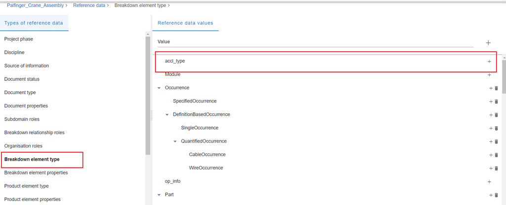

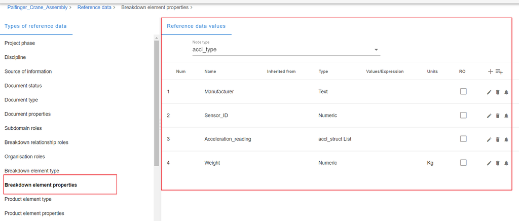

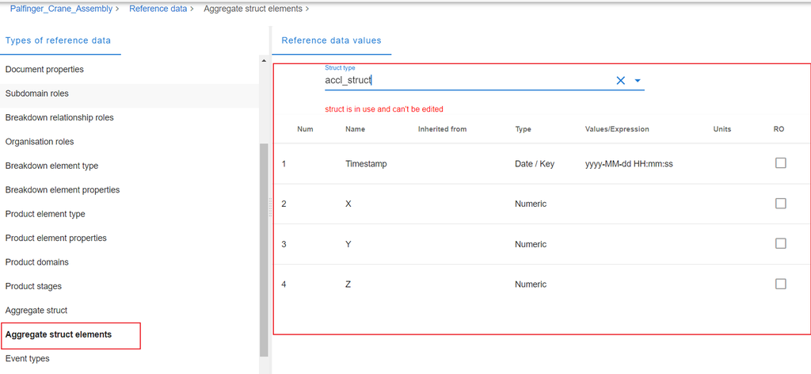

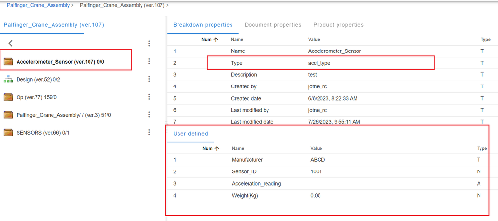

```python
#####################  Updating breakdown element Property information  ######################

def update_breakdown_element_prop(model,node,upload_prop_data,token,repository="TruePLMprojectsRep"):

    update_prop_url = PLM_URL + "/api/bkd/prop/" + repository + "/" + model + "/" + node + "/"  + token
    print("\nPerforming request: " + update_prop_url)

    try:
        response = requests.post(update_prop_url,data = upload_prop_data, timeout=2.0)
        response.raise_for_status()
        return response.json() if response.ok else None
    except requests.exceptions.RequestException as e:
        print('Request failed {}\nError Message:  {}'.format(e, response.text))
        return None

model= 'Palfinger_Crane_Assembly'     # Project name

# Breakdown element properties

upload_prop_data={
     'act_timestamp':'',
     'props': ["urn:rdl:Palfinger_Crane_Assembly:Manufacturer","urn:rdl:Palfinger_Crane_Assembly:Sensor_ID","urn:rdl:Palfinger_Crane_Assembly:Weight"],
     'ptypes': ['string','N','N'],
     'units':["","","Kg"],
     'vals': ['ABCD',1001,0.05]}


search_params={ "case_sens":"false",
                "domains":"ID",
                "folder_only":"true",
                "node":"",
                "page":"",
                "page_size":"",
                "pattern":"Accelerometer_Sensor",   # Required Breakdown element name
                "props":""}

token = get_token(getTokenData)
if token:
    node=str(bd_quick_search(model,'q_search',search_params,token)[0]['bkdn_elem_info']['instance_id']) # Required node number
    print('The required breakdown element Instance Id:',node)
    if node:
        upload_result=update_breakdown_element_prop(model,node,upload_prop_data,token)
        if upload_result:
            pp.pprint(upload_result)
```

#### 10.API call for uploading Aggregate data to a breakdown element

[output not shown]

```python
# The example for a JList of JSON format data for uploading is shown below
#and the aggregate properties are created for the element in EDMtruePLM to store
#accelerometer sensor values and it contains timestamp, acceleration in x,y,z directions

# [{"Timestamp": "2023-04-18 09:30:03", "X": 14, "Y": -2, "Z": 9},
#  {"Timestamp": "2023-04-18 09:30:04", "X": -4, "Y": -5, "Z": -3},
#  {"Timestamp": "2023-04-18 09:30:05", "X": 12, "Y": 0, "Z": -2},
#  {"Timestamp": "2023-04-18 09:30:06", "X": 13, "Y": 0, "Z": 9},
#  {"Timestamp": "2023-04-18 09:30:07", "X": 0, "Y": -9, "Z": 5}]

# The example for uploading data in a CSV format data is shown below

# Timestamp,X,Y,Z
# 2023-04-10 15:30:18,-2,-7,7
# 2023-04-10 15:30:19,8,7,-7
```

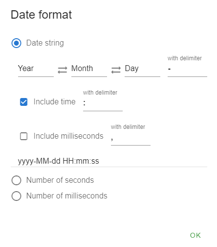

[figure not shown]

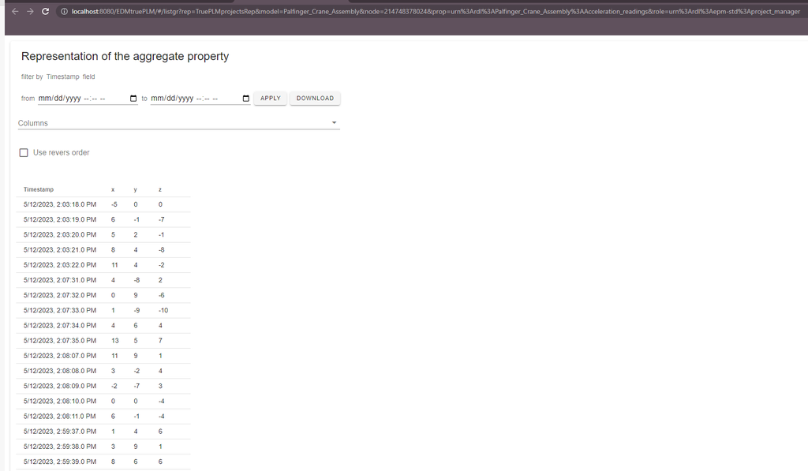

```python
#####################  Uploading aggr data  ######################

# Generating random data for uploading
def generating_sample_data(no_of_records):
    data_accl = []
    for _ in range(no_of_records):
        time.sleep(1)
        currentTimeStamp = datetime.datetime.now().strftime("%Y-%m-%d %H:%M:%S")
        currentx = random.randrange(-5, 15)
        currenty = random.randrange(-10, 10)
        currentz = random.randrange(-10, 10)

        data_accl.append({"Timestamp": currentTimeStamp, "X": currentx, "Y": currenty, "Z": currentz})

    # Writing data to JSON file
    with open("accl_new_file.json", "w") as file:
        json.dump(data_accl, file)
    print("\tData written to accl_new_file.json")

    # Writing data to CSV file
    df_csv = pd.DataFrame(data_accl)
    df_csv.to_csv("accl_new_file.csv", index=False)
    print("\tData written to accl_new_file.csv")
    return

def upload_data(file_path, url_type, model, node, prop,token,repository = "TruePLMprojectsRep"):

    if url_type == 'JSON':
        url_format = "/api/bkd/aggr/{}/{}/{}/{}/{}".format(repository, model, node, prop, token)
    elif url_type == 'CSV':
        url_format = "/api/bkd/aggr_csv/{}/{}/{}/{}/{}".format(repository, model, node, prop, token)
    else:
        print('Invalid URL type')
        return

    url = PLM_URL + url_format

    print("\nPerforming request: " + url)
    try:
        with open(file_path, "r") as file:
            response = requests.post(url, files={"file": file}, timeout=2.0)
            response.raise_for_status()
            return response.json() if response.ok else None
    except requests.exceptions.RequestException as e:
        print('Request failed {}\nError Message:  {}'.format(e, response.text))
    return None


# Input parameters

no_of_records=1                                     # required no of records to upload

generating_sample_data(no_of_records)

file_path = "accl_new_file.json"
url_type = "JSON"                                    # Change this to "CSV" if needed
model = "Palfinger_Crane_Assembly"
prop = "urn:rdl:" + model + ":Acceleration_reading"  # porperty
search_params={ "case_sens":"false",
                "domains":"ID",
                "folder_only":"true",
                "node":"",
                "page":"",
                "page_size":"",
                "pattern":"Accelerometer_Sensor",   # Required Breakdown element name
                "props":""}

token = get_token(getTokenData)
if token:
    node=str(bd_quick_search(model,'q_search',search_params,token)[0]['bkdn_elem_info']['instance_id']) # Required node number
    print('The required breakdown element Instance Id:',node)
    if node:
        upload_result=upload_data(file_path, url_type, model, node, prop,token)
        if upload_result:
            print('Data uploaded to the Instance {}'.format(node))
```

#### 11.API call to Export aggregate data from breakdown elements (Method 1)

```
To download aggregate data the following API calls are required:

1./api/bkd/aggr_exp/{repository}/{model}/{node}/{prop}/{token}, Export the values of the aggregated property with paging and filtering to the JSON format

2. /api/dat/file/data/{src}/{name}/{token}, Return file data for download

The first method takes inputs parameters to get data in required format either CSV or JSON . This method will generate
file properties as shown in below example.

    {'descr': None,
    'source': 'aggr6673349257703198929down',
    'contentType': None,
    'discipline': None,
    'projPhase': None,
    'status': None,
    'editor': None,
    'resp': None,
    'rev': None,
    'app': None,
    'revMan': None,
    'title': 'Accleration_readings_data.csv',
    'isNewIssue': False}

The source and title values are supplied to the second API function from this response.

The example for output response in csv format is shown below

Timestamp,X,Y,Z

2023-04-11 06:31:04,0,-6,-9
2023-04-11 06:31:05,12,-4,8
2023-04-11 06:31:06,9,7,-9

The example for output resposne in JSON  format is shown below

[{"Timestamp":"2023-04-11 06:31:04","X":"0","Y":"-6","Z":"-9"},
{"Timestamp":"2023-04-11 06:31:05","X":"12","Y":"-4","Z":"8"},
{"Timestamp":"2023-04-11 06:31:06","X":"9","Y":"7","Z":"-9"}]
```

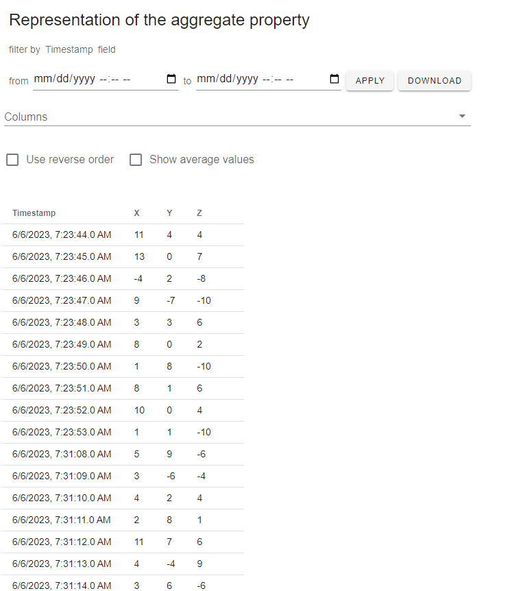

```python
#####################  downloading aggr data  ######################


def get_data_prop(model,node,prop,data_params,token,repository="TruePLMprojectsRep"):

    download_data_file_prop = PLM_URL + "/api/bkd/aggr_exp/" + repository + "/" + model + "/" + node + "/" + prop + "/" + token

    print("\nPerforming request:", download_data_file_prop)
    try:
        response = requests.get( download_data_file_prop,params=data_params, timeout=2.0)
        response.raise_for_status()
        return response.json() if response.ok else None
    except requests.exceptions.RequestException as e:
        print('Request failed {}\nError Message:  {}'.format(e, response.text))
        return None

def aggr_download_data(file_prop,token):

    if file_prop:
        print('The rerquired file properties',file_prop)
        download_data_url = PLM_URL+"/api/dat/file/data/"+file_prop['source']+"/"+file_prop['title']+"/"+token

        print("\nPerforming request:",download_data_url)

        try:
            response = requests.get(download_data_url, timeout=2.0)
            response.raise_for_status()
            return response.json() if response.ok else None
        except requests.exceptions.RequestException as e:
            print('Request failed {}\nError Message:  {}'.format(e, response.text))
            return None
    else:
        print('Not valid file properties')


model="Palfinger_Crane_Assembly"                      # porject name

prop = "urn:rdl:" + model + ":Acceleration_reading"  # porperty

data_params={'from':"",               # date format for should be unix format with milliseconds(example:1686029024000)
            'to':"",
            'format':'json',          # csv or json
            'cols':[]}                # Example to select required cols ['x','z']

search_params={ "case_sens":"false",
                "domains":"ID",
                "folder_only":"true",
                "node":"",
                "page":"",
                "page_size":"",
                "pattern":"Accelerometer_Sensor",   # Required Breakdown element name
                "props":""}

token = get_token(getTokenData)
if token:
    node=str(bd_quick_search(model,'q_search',search_params,token)[0]['bkdn_elem_info']['instance_id']) # Required node number
    print('The required breakdown element Instance Id:',node)
    if node:
        data = get_data_prop(model, node, prop, data_params, token)
        if data:
            data_response = aggr_download_data(data, token)
            if data_response:
                print(data_response)
```

#### 12.API call to Export aggregate data from Breakdown elements (Alternate method 2)

```
To download aggregate data the following API is required. which returns the records in a array of values.

GET /api/bkd/aggr/{repository}/{model}/{node}/{prop}/{token} Return the values of the aggregated property
with paging and filtering.

This method returns the records in reverse order if-required.
```

```python
def get_data_aggr(model,node,prop,data_params,token,repository="TruePLMprojectsRep"):

    download_aggr_data = PLM_URL + "/api/bkd/aggr/" + repository + "/" + model + "/" + node +\
    "/" + prop + "/" + token

    print("\nPerforming request:", download_aggr_data)
    try:
        response = requests.get(download_aggr_data,params=data_params, timeout=2.0)
        response.raise_for_status()
        return response.json() if response.ok else None
    except requests.exceptions.RequestException as e:
        print('Request failed {}\nError Message:  {}'.format(e, response.text))
        return None

#################### parameters required #############

model="Palfinger_Crane_Assembly"                      # porject name
prop = "urn:rdl:" + model + ":Acceleration_reading"  # porperty

data_params={'from':"",             # date format should be unix with milliseconds(example:1686029024000)
            'to':"",                # date format should be unix with milliseconds(example:1686029024000)
            'format':'',            # csv or json
            'page':'',
            'size':'',
            'reverse_order':''}     # Use reverse order of the records

search_params={ "case_sens":"false",
                "domains":"ID",
                "folder_only":"true",
                "node":"",
                "page":"",
                "page_size":"",
                "pattern":"Accelerometer_Sensor",   # Required Breakdown element name
                "props":""}

token = get_token(getTokenData)
if token:
    node=str(bd_quick_search(model,'q_search',search_params,token)[0]['bkdn_elem_info']['instance_id']) # Required node number
    print('The required breakdown element Instance Id:',node)
    if node:
        data=get_data_aggr(model,node,prop,data_params,token)
        if data:
            print(data)
```

#### 13.API call to Export aggregate data in Breakdown elements (Alternate method 3)

```
This method is available from PLM version 3.5 and this gives us the data export options in either CSV or JSON format and reduces the  need for using multiple API methods to export data.

/api/bkd/aggr_exp_dt/{repository}/{model}/{node}/{prop}/{token} Export the values of the aggregated property with paging and filtering to the JSON format
```

```python
#####################  downloading sensor data  ######################

def download_aggr_data(model,node,prop,data_params,token,repository="TruePLMprojectsRep"):

    get_filtered_data_url =PLM_URL+ "/api/bkd/aggr_exp_dt/" + repository + "/" + model + "/" + node + \
                                                                                          "/" + prop + "/"+token
    print("\nPerforming request:",get_filtered_data_url)

    try:
        response = requests.get(get_filtered_data_url, params=data_params,timeout=2.0)
        response.raise_for_status()
        return response.json() if response.ok else None
    except requests.exceptions.RequestException as e:
        print('Request failed {}\nError Message:  {}'.format(e, response.text))
        return None

model="Palfinger_Crane_Assembly"                      # project name

prop = "urn:rdl:" + model + ":Acceleration_reading"  # porperty

data_params={'from':"",             # date format should be unix with milliseconds(example:1686029024000)
            'to':"",
            'format':'json',                     # csv or json
            'cols':['X','Z']}                    # cols ['x','z']


search_params={ "case_sens":"false",
                "domains":"ID",
                "folder_only":"true",
                "node":"",
                "page":"",
                "page_size":"",
                "pattern":"Accelerometer_Sensor",   # Required Breakdown element name
                "props":""}

token = get_token(getTokenData)
if token:
    node=str(bd_quick_search(model,'q_search',search_params,token)[0]['bkdn_elem_info']['instance_id']) # Required node number
    print('The required breakdown element Instance Id:',node)
    if node:
        data=download_aggr_data(model,node,prop,data_params,token)
        if data:
            print(data)
```

#### 14.API call for Uploading a file to break down element

```
The method is used for uploading a file to a breakdown element /api/dat/{repository}/{model}/{node}/{token}

This method can be used to upload any file like (excel, pdf, word, images).

In the below figure the user has uploaded a file in Maintenance data breakdown element
```

[figure not shown]

```python
def upload_file(data_param,file_to_upload,model,node,token,repository="TruePLMprojectsRep"):

    url_upload_file=PLM_URL+"/api/dat"+"/"+repository + "/" + model + "/" + node + "/"+token

    print("\nPerforming request: " + url_upload_file)

    try:
        response = requests.post(url_upload_file,files= {"file" : file_to_upload },data=data_param,timeout=5.0)
        response.raise_for_status()
        return response.json() if response.ok else None
    except requests.exceptions.RequestException as e:
        print('Request failed {}\nError Message:  {}'.format(e, response.text))
        return None

# Input Parameters required for file upload

file_path = "test_file.pdf"                                 # file path to upload
file_to_upload = open(file_path, "rb")

data_param={'descr':"maintenance information",              # Description of the document
           'title':"test_file",                             # Title of the document
           'source':"urn:rdl:epm-std:Unknown",              # Source of the document
           'contentType':'urn:rdl:epm-std:Miscellaneous',   # Content type of the document
           'discipline':'urn:rdl:epm-std:Uncertain',        # Discipline of the document
           'projPhase':'urn:rdl:epm-std:0',                 # Project phase of the document
           'status':'urn:rdl:epm-std:Approved',             # Status of the document
           'editor':'jotne_rc',                             # Login of person, who edited the document
           'resp':'jotne_rc',                               # Login of person, who responsible for the document
           'rev':'jotne_rc',                                # Login of person, who reviewed the document
           'app':'jotne_rc',                                # Login of person, who approved the document
           'revMan':'jotne_rc'}                             # Login of person, who is the release manager for the document


model="Palfinger_Crane_Assembly"     # Project name

search_params={ "case_sens":"false",
                "domains":"ID",
                "folder_only":"true",
                "node":"",
                "page":"",
                "page_size":"",
                "pattern":"Maintenance data",    # breakdown element where the file need to be uploaded ( Maintenance data element)
                "props":""}

token = get_token(getTokenData)
if token:
    node=str(bd_quick_search(model,'q_search',search_params,token)[0]['bkdn_elem_info']['instance_id']) # Required node number
    print('The required breakdown element Instance Id:',node)
    if node:
        data=upload_file(data_param,file_to_upload,model,node,token)
        if data:
            print(data)
```

#### 15.API call for documents quick search method

```
This method is used for searching documents in a project.

/api/dat/q_search/{repository}/{model}/{token} quick Search for the documents

If multiple files with the same file name exist in different breakdown elements, a search request for that filename will return all matching files found within those breakdown elements. To narrow down the search results and find files within a specific breakdown element the user can specify the Breakdown Element Instance ID in :

            data_param {'node':'required_breakdown_element_instance_id'}

which serves as the root of the relevant branch in the search parameters. This allows the search to be limited to the desired location, providing more targeted results.
```

[figure not shown]

```python
def doc_quick_search(data_param,model,token,repository="TruePLMprojectsRep"):

    doc_search_url=PLM_URL+"/api/dat/q_search"+"/"+repository + "/" + model + "/"+token
    print("\nPerforming request: " + doc_search_url)

    try:
        response = requests.get(doc_search_url,params=data_param,timeout=2.0)
        response.raise_for_status()
        return response.json() if response.ok else None
    except requests.exceptions.RequestException as e:
        print('Request failed {}\nError Message:  {}'.format(e, response.text))
        return None

# parameters required for breakdown element quick search method
node_search_params={ "case_sens":"false",
                "domains":"ID",
                "folder_only":"true",
                "node":"",
                "page":"",
                "page_size":"",
                "pattern":"Maintenance data",  # breakdown element where the file need to be searched ( Maintenance data element)
                "props":""}

# parameters required for document quick search method

data_param={'case_sens':'no',    # Use case sensitive search or not
            'domains':'ID',      # CSV list of subjects for search, can include ID, DESCRIPTION, CLASS, PROPERTY
            'node':'',           # Breakdown element instance id - root of interesting branch
            'page':'',           # Start page of output
            'page_size':'',      # Page size of output
            'pattern':'test_file', # Search string pattern (for LIKE operations in EXPRESS)
            'props':''}            # CSV list of property names where to apply search pattern

model="Palfinger_Crane_Assembly"     # Project name

token = get_token(getTokenData)

if token:
    required_node=str(bd_quick_search(model,'q_search',node_search_params,token)[0]['bkdn_elem_info']['instance_id'])
    if required_node:
        data_param['node']= required_node
        search_result=doc_quick_search(data_param,model,token)
        if search_result:
            pp.pprint(search_result)
```

#### 16.API call for document advance search method

```
This method is used for searching documents in a project.

/api/dat/a_search/{repository}/{model}/{token} Advanced search for the documents
```

```python
def document_advanced_search(data_param,model,token,repository="TruePLMprojectsRep"):

    doc_search_url=PLM_URL+"/api/dat/a_search"+"/"+repository + "/" + model + "/"+token

    print("\nPerforming request: " + doc_search_url)

    try:
        response = requests.get(doc_search_url,params=data_param,timeout=2.0)
        response.raise_for_status()
        return response.json() if response.ok else None
    except requests.exceptions.RequestException as e:
        print('Request failed {}\nError Message:  {}'.format(e, response.text))
        return None


model="Palfinger_Crane_Assembly"     # Project name

# parameters required for node quick search method
node_search_params={ "case_sens":"false",
                "domains":"ID",
                "folder_only":"true",
                "node":"",
                "page":"",
                "page_size":"",
                "pattern":"Maintenance data",  # breakdown element where the file need to be searched ( Maintenance data element)
                "props":""}

# parameters required for doduemnt search

data_param={ 'approver':'',         # Search value for the document approver person
            'checkOutUser':'',      # Search for the documents checked out by the specified person
            'createAfter':'',       # Search for the document created after the specified date
            'createBefore':'',      # Search for the document created before the specified date
            'createUser':'',        # Search for the documents created by the specified person
            'dataType':'',          # Search value for the document data type
            'descipline':'',        # Search value for the document discipline
            'descr':'maintenance information',             # Search pattern for the document description
            'docSource':'',         # Search value for the document source
            'docStatus':'',         # Search value for the document status
            'docType':'',           # Search value for the document type
            'editAfter':'',         # Search for the document edited after the specified date
            'editBefore':'',        # Search for the document edited before the specified date
            'editUser':'',          # Search for the documents edited by the specified person
            'editor':'',            # Search value for the document editor person
            'extVer':'',            # Search value for the document external version
            'limit':'',             # Limit for the number of search result
            'nodeID':'',            # Root element’s instance ID of the branch to search within
            'nodeVer':'',           # Version number of the element to search within
            'onlyCheckOut':'false', # Search for the checked out documents only
            'onlyRedFlag':'false',  # Search for the documents with the read flag only
            'onlyStickyNote':'false', # Search for the documents with the sticky notes only
            'pPhase':'',              # Search value for the document project phase
            'propName':'',            # List of the document property names to search for
            'propVal':'',             # List of the document property values to search for
            'rManager':'',            # Search value for the document release manager person
            'responsible':'',         # Search value for the document responsible person
            'reviewer':'',            # Search value for the document reviewer person
            'rid':'',                 # Search value for the document RID
            'submitAfter':'',         # Search for the document submitted after the specified date
            'submitBefore':'',        # Search for the document submitted before the specified date
            'title':'test_file'    }           # Search pattern for the document title

token = get_token(getTokenData)
if token:
    required_node=str(bd_quick_search(model,'q_search',node_search_params,token)[0]['bkdn_elem_info']['instance_id'])
    if required_node:
        data_param['nodeID']= required_node
        search_result=document_advanced_search(data_param,model,token)
        if search_result:
            print(search_result)
```

#### 17.API call for downloading documents from the break down element

```
The method required for downloading file from a project is shown below:
/api/dat/file/link/{repository}/{model}/{token} Prepare the file of the document for download.

The response which contains required file properties that are required download, and these are supplied to the below API method
/api/dat/file/data/{src}/{name}/{token} Return file data for download
```

```python
def download_data(file_prop,token):
    print(file_prop)

    download_data_url = PLM_URL+"/api/dat/file/data/"+file_prop['source']+"/"+file_prop['title']+"/"+token

    print("\nPerforming request:",download_data_url)

    try:
        response = requests.get(download_data_url, timeout=2.0)
        response.raise_for_status()
        return response if response.ok else None
    except requests.exceptions.RequestException as e:
        print('Request failed {}\nError Message:  {}'.format(e, response.text))
        return None

def get_doc_file_prop(data_param,model,token,repository="TruePLMprojectsRep"):

    url_download_file=PLM_URL+"/api/dat/file/link"+"/"+repository + "/" + model+"/"+token
    try:
        response = requests.get(url_download_file,params=data_param,timeout=2.0)
        response.raise_for_status()
        return response.json() if response.ok else None
    except requests.exceptions.RequestException as e:
        print('Request failed {}\nError Message:  {}'.format(e, response.text))
        return None

model="Palfinger_Crane_Assembly"     # Project name

#parameters required for document quick search method
data_param={'case_sens':'no',    # Use case sensitive search or not
            'domains':'ID',      # CSV list of subjects for search, can include ID, DESCRIPTION, CLASS, PROPERTY
            'node':'',           # Breakdown element instance id - root of interesting branch
            'page':'',           # Start page of output
            'page_size':'',      # Page size of output
            'pattern':'test_file', # Search string pattern (for LIKE operations in EXPRESS)
            'props':''}            # CSV list of property names where to apply search pattern


# parameters required for breakdown element quick search method
node_search_params={ "case_sens":"false",
                "domains":"ID",
                "folder_only":"true",
                "node":"",
                "page":"",
                "page_size":"",
                "pattern":"Maintenance data",  # breakdown element where the file need to be searched ( Maintenance data element)
                "props":""}


doc_data_param={'name':'',  # required file name to dowload
           'ver':''}         # instance id of document can be obtained from document (q_search or a_search)

token=get_token(getTokenData)

if token:
    required_node=str(bd_quick_search(model,'q_search',node_search_params,token)[0]['bkdn_elem_info']['instance_id'])
    if required_node:
        data_param['node']= required_node
        doc_search_result=doc_quick_search(data_param,model,token)
    if doc_search_result:
        doc_data_param['name']=str(doc_search_result[0]['doc_info']['file_name'])
        doc_data_param['ver']=str(doc_search_result[0]['doc_info']['instance_id'])
        file_properties=get_doc_file_prop(doc_data_param,model,token)
        if file_properties:
            file_data=download_data(file_properties,token)
            if file_data:
                required_filename = Path('downloaded_test_file.pdf')
                required_filename.write_bytes(file_data.content)
                print('The file has downloaded')
```

#### 18.API call for Deleting Document in Break down elements

```
This method is used for deleting the documents in the project. This requires 'ass_doc_instance_id' as a
input parameter which deletes required document.
This information can be obtained from document quick search or advanced search methods.

#/api/dat/{repository}/{model}/{doc}/{token}     Delete document from the breakdown element
```

```python
#####################  Deleting documents  ######################

def doc_delete(ass_doc_instance_id,token,repository="TruePLMprojectsRep"):

    del_doc_url=PLM_URL+"/api/dat"+"/"+repository+"/"+model+"/"+ass_doc_instance_id+"/"+token
    print("\nPerforming request: "+del_doc_url)
    try:
        response=requests.delete(del_doc_url,timeout=2.0)
        response.raise_for_status()
        return response.json() if response.ok else None
    except requests.exceptions.RequestException as e:
        print('Request failed {}\nError Message:  {}'.format(e, response.text))
        return None

model="Palfinger_Crane_Assembly"     # Project name


# parameters required for breakdown element quick search method
node_search_params={ "case_sens":"false",
                "domains":"ID",
                "folder_only":"true",
                "node":"",
                "page":"",
                "page_size":"",
                "pattern":"Maintenance data",  # breakdown element where the file need to be searched ( Maintenance data element)
                "props":""}


data_param={'case_sens':'no',    # Use case sensitive search or not
            'domains':'ID',      # CSV list of subjects for search, can include ID, DESCRIPTION, CLASS, PROPERTY
            'node':'',           # Breakdown element instance id - root of interesting branch
            'page':'',           # Start page of output
            'page_size':'',      # Page size of output
            'pattern':'test_file', # Search string pattern (for LIKE operations in EXPRESS)
            'props':''}            # CSV list of property names where to apply search pattern

token=get_token(getTokenData)
if token:
    required_node=str(bd_quick_search(model,'q_search',node_search_params,token)[0]['bkdn_elem_info']['instance_id'])
    if required_node:
        data_param['node']= required_node
        doc_search_result=doc_quick_search(data_param,model,token)
    if doc_search_result:
        ass_doc_instance_id=str(doc_search_result[0]['doc_info']['ass_doc_instance_id'])  #Document ass_doc_instance_id obtained from q_search or a_search
        if ass_doc_instance_id:
            doc_delete(ass_doc_instance_id,token)
            print('file has been deleted')
```